Author

Government Analysis Function and ONS Data Science Campus

> To switch between light and dark modes, use the toggle in the top left

# 1 Learning Objectives

- Be familiar with data structures in R.
- Understand how vectors operate.
- Be familiar with lists.
- Be familiar with data frames and tibbles.

# 2 Data Structures

We rarely work with single data values, we often work with a combination or collection of data.

R organises these in certain structures, and stores this data so that we can manipulate and work with it.

# 3 Vectors

In the previous chapter we looked at variables, where we said we could assign a name to a value.

Crucially, each of these values (and by extension the variable itself) has an associated datatype.

In the below example, we create a variable with the **character** data type.

```r
# To assign a variable

my_friends <- "ian"
```

Suppose you wanted to store more than one value in “my_friends”, e.g “hannah”, “mike”, “almas”.

The following seem like possible solutions to this problem, but unfortunately are not the correct way to store multiple data points.

```r
# This code will throw an error

my_friends <- "ian", "hannah", "mike", "almas"

my_friends <- ("ian", "hannah", "mike", "almas")
```

You will get the error below,

> **Error: unexpected ‘,’ in “my_friends <-”ian”,“**

as the comma should not be used in this way.

This brings us to the **c()** function.

## 3.1 The c() Function

The “c()” function is used for creating a vector in R, which is it’s most simple data structure. The c stands for **combine**.

```r
#To access the R help documentation

?c()

# or

help(c)
```

We can use this function to store multiple elements (data points) in a single variable, with each element **separated by a comma**.

```r
# Creating a vector

my_friends <- c("ian", "hannah", "mike", "almas")

# To display the data

my_friends
```

```
[1] "ian"    "hannah" "mike"   "almas"
```

Let’s check the datatype of our new vector.

```r
# Check datatype of my_friends

typeof(my_friends)
```

```
[1] "character"
```

We see that this is a character vector, a.k.a, a vector containing character data. This is because each element contained within the vector are character type.

## 3.2 Vector Definition

A vector is a collection of values that are **all of the same type** (doubles, characters, etc.).

Since R insists all elements in a vector have to be of the same type we then can have types of vectors. These are:

- Logical vector - contains only logical values.
- Numerical vector - contains only numerical values.
- Character vector - contains only character values.

There are more types of vectors, but for the purpose of our learning these are sufficient.

Visually:

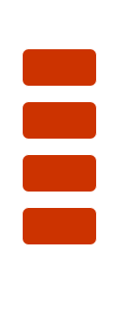

## 3.3 Creating Vectors

There are several different ways of creating a vector. You can create a vector by using:

- The combine function **c()** that we saw previously.
- The sequence function **seq()** to create any sequence of numbers.
- The **colon** operator to create a vector of consecutive numbers.

### 3.3.1 The c() function (combine)

Let’s create a numeric vector with c() this time!

```r
# Creating a vector using the combine function

sample_vector <- c(1, 2, 3, 4, 5)

# To display the created vector

sample_vector
```

```
[1] 1 2 3 4 5
```

### 3.3.2 The seq() function (sequence)

A sequence of values has:

- A starting point
- An ending point
- A “step”, a.k.a the value we jump by from number to number.

> For example, if we start at 2, end at 10 and step by 2 we will have (2, 4, 6, 8, 10) as our final sequence.

The seq() function takes the arguments:

- from - the start point
- to - the end point
- by - the step value

```r
# Creating a vector using the sequence function,

sequence_vector <- seq(from = 2, to = 6, by = 2)

# To display the created vector

sequence_vector
```

```
[1] 2 4 6
```

Earlier we saw in the console the number [1] next to our output. This represents the position of the element to the right of this number in the vector.

Thus, 2 is element 1 of our vector, 4 is element 2 and so on. This is essential information for later.

### 3.3.3 The Colon Operator

A range of values (i.e., consecutive values) could be generated as a vector using a colon **:** in R.

Since this is consecutive, we can’t have broken sequences like seq() allows.

```r
# Creating a vector using a colon

colon_vector <- 6:10

# To display the created vector

colon_vector
```

```
[1]  6  7  8  9 10
```

### 3.3.4 Exercise

**Exercise**

1. Create two vectors, one with numeric data and one with character data and name them appropriately. For example favourite_movies, lucky_numbers.
2. Use the c() function to create a new vector with your vectors as inputs. This combines the smaller vectors into a larger vector, further showcasing their versatility.
3. Find the type of your new vector. Why do you think this is the case?

**Show Answer**

```r
# Creating a character vector

favourite_movies <- c("Frozen", "The Lion King", "Moana", "The Dark Knight")

# To display the data

favourite_movies
```

```
[1] "Frozen"          "The Lion King"   "Moana"           "The Dark Knight"
```

```r
# Creating a numeric vector

lucky_numbers <- c(7, 12, 15, 1)

# To display the data

lucky_numbers
```

```
[1]  7 12 15  1
```

```r
# Creating a vector of vectors

movies_and_numbers <- c(favourite_movies, lucky_numbers)

movies_and_numbers
```

```
[1] "Frozen"          "The Lion King"   "Moana"           "The Dark Knight"
[5] "7"               "12"              "15"              "1"
```

```r
# Checking the type of vector

typeof(movies_and_numbers)
```

```
[1] "character"
```

We end up with a character vector as opposed to an error for incompatible types (numeric and character).

As vectors are supposed to be of the same data type, R will convert values so that they are all the same datatype. This is called **coercion**, which works on a complex heirarchy:

- Any datatype can be converted to a character by wrapping it in quotation marks **” “**.
- Any integer can be converted to a double by adding in the decimal place, i.e. 1L –> 1.0
- Any logical can be converted to an integer or double as they have numeric representation as 1 and 0 (or 1.0, 0.0) in the background.

However, a character such as “hello” cannot be converted to any other type.

As such, we have:

> **Logical < Integer < Double < Character** and we see that character is the most all encompassing, with logicals being converted from but not to.

## 3.4 Vectorised Language

Vectors aren’t just containers for homogeneous data (data of the same type).

> **As R is a vectorised language, this means operations are applied to each element of the vector automatically, without the need to loop through the vector.**

This is not a common behaviour among programming languages and is a key advantage of R’s nature as a vectorised language.

This also means that every variable we have created so far have also been vectors with one element, and the operators (such as adding 5 to them) have been vectorised operations.

Let’s see this in practice!

```r
# Add sample and colon vector

vector_addition <- sample_vector + colon_vector


vector_addition
```

```
[1]  7  9 11 13 15
```

We see that each first element is added, each second element is added and so on, this is an element wise operation (element by element).

```r
# Multiplying vectors (element wise)

vector_multiplication <- sample_vector * colon_vector


vector_multiplication
```

```
[1]  6 14 24 36 50
```

We see that each first element is multiplied, each second element is multiplied and so on.

```r
# Multiply vector by a value

sample_vector <- sample_vector * 3


sample_vector
```

```
[1]  3  6  9 12 15
```

We see that each element is multiplied by 3, like expanding a bracket!

### 3.4.1 Exercise

**Exercise**

1. Try and add “sample_vector” and “sequence_vector”.
2. Can you figure out what has happened?

**Show Answer**

```r
# Adding two vectors of different lengths

vector_after_addition <- sample_vector + sequence_vector
```

```
Warning in sample_vector + sequence_vector: longer object length is not a
multiple of shorter object length
```

```r
vector_after_addition
```

```
[1]  5 10 15 14 19
```

2. Here we have one vector with 3 elements and one with 5 elements. The number of elements in a vector is referred to as the **length** of the vector, so sample vector has length 5.

When we try to add vectors of different lengths R gives a warning message as the **longer object length is not a multiple of the shorter object length**.

As we can see R has recycled the elements in the shorter vector, wrapped them around to reach the length of the longer one, before adding them together.

When applying arithmetic to two vectors their lengths should either be equal, or the length of the longer one a multiple of the length of the shorter one, i.e. adding a vector of length 3 to a length 6.

## 3.5 Indexing a Vector

Often, we want to select specific elements or ranges of them to work with going forward.

Elements in a vector can be selected using square brackets **[ ]**.

> **We are going to use indexes, which are the position of each element within the vector.**

Note that R indexes start at 1 (not 0 like other languages).

## **Example - Indexing a single element**

Take the favourite_movies vector from the earlier exercise.

```r
# To display the vector

favourite_movies
```

```
[1] "Frozen"          "The Lion King"   "Moana"           "The Dark Knight"
```

If we want to select “The Lion King” from this vector, which is at position 2, we need to use the number 2 in square brackets.

```r
# Selecting the second element in the vector

favourite_movies[2]
```

```
[1] "The Lion King"
```

Reading this left to right we are:

- From the favourite_movies vector
- Select [ ]
- The element at position 2

## **Example - Index Sequentially**

We can also index multiple elements using the colon operator. Remember that this creates a sequence of consecutive numbers, so allows us to index sequentially.

For example, if we wanted to select from “The Lion King” to “The Dark Knight”, we select from index 2 to index 4, i.e. **2:4**.

```r
# Selecting sequentially

favourite_movies[2:4]
```

```
[1] "The Lion King"   "Moana"           "The Dark Knight"
```

## **Example - Index out of sequence**

We can even index **out of sequence**, such as obtaining the elements at indexes 1, 3 and 4.

This is interesting as most other programming languages require external packages to be able to do this, whereas R does it out of the box.

To do this, we need to create a vector of values inside the square brackets, using the c() function.

```r
# Selecting first, third and fourth items

favourite_movies[c(1,3,4)]
```

```
[1] "Frozen"          "Moana"           "The Dark Knight"
```

### 3.5.1 Exercise

**Exercise**

Use the vector below containing days of the week (Monday - Sunday), for the exercises.

```r
# Days of the week vector

days_of_the_week <- c("Monday",
                      "Tuesday",
                      "Wednesday",
                      "Thursday",
                      "Friday",
                      "Saturday",
                      "Sunday")
```

1. Select Wednesday only.
2. Select the week days.
3. Select Tuesday and Thursday.

**Show Answer**

```r
# Selecting Wednesday

days_of_the_week[3]
```

```
[1] "Wednesday"
```

```r
# Selecting the week days

days_of_the_week[1:5]
```

```
[1] "Monday"    "Tuesday"   "Wednesday" "Thursday"  "Friday"
```

```r
# Selecting Tuesday and Thursday

days_of_the_week[c(2,4)]
```

```
[1] "Tuesday"  "Thursday"
```

**Extension Exercise**

Run the following lines of code one at a time and try to determine what is happening.

```r
# Find out what the code below does

days_of_the_week[3] <- "Wensday"


# Find out what the code below does

days_of_the_week[c(-6,-7)]

# Find out what the code below does

days_of_the_week[8]
```

**Extension Answer**

- The first line of code modifies the element at index position 3 and overwrites it (notice the assignment operator) to something else.
- Using the minus sign when selecting elements reverses the process, i.e. tells R **not** to select that value. So here we are saying select all except index positions 6 and 7.
- Giving an index position outside of the range of vector elements returns **NA (Not Available)** as there is no 8th value in the vector.